# Medidas de tendencia central

[Kevin Imanol Israel Moreno López](https://github.com/israelkevinmoreno/israelmk.github.io)

Estadística Taller 4, 2022-2, Facultad de economía](http://www.economia.unam.mx/)

2/3/2022

### 1. ¿Qué son las medidas de tendencia central? 🤔

> Definición: “La **medida de tendencia central** (moda,media y mediana), **parámetro de tendencia central** o **medida de centralización** es un número ubicado hacia el centro de la distribución de los valores de una serie de observaciones (medidas), en la que se encuentra ubicado el conjunto de los datos. Las medidas de tendencia central más utilizadas son: media, mediana u moda. Cuando se hace referencia únicamente a la posición de estos parámetros dentro de la distribución, independientemente de que esté más o menos centrada, se habla de estas medidas como **medidas de posición**.”

[Wikipedia (2022)](https://es.wikipedia.org/wiki/Medidas_de_tendencia_central)

Para este ejemplo, primero generaremos una serie de **100** números aleatorios entre **1** y **20** mediante la función `sample`. El argumento `TRUE` nos permitirá generar una muestra con remplazo:

```r
numeros <- sample(1:20, 100, TRUE)
numeros
```

```
##   [1]  9 15  4 16 11  6 11 14  8 13 13 12  6 19 17 12 11 10 15  5 17  4  8 16 10
##  [26] 13  5 12 14  7 10  5 18 12  9 14  7 14  6  4  1 10  9  8 18 18  2  6  8 18
##  [51]  6 17 17 17  2  7  3  1 19 16  2 16  6 11 10  1  6 17 13  6  8  6 14 16 20
##  [76] 20 11 11  5 19  5 19  9 12 17 20 12 12 13 19  7 16 20  1 13 13 15 13 12  5
```

### 2. Mediana 📍

> Definición: “En el ámbito de la [estadística](https://es.wikipedia.org/wiki/Estad%C3%ADstica), la **mediana** (del latín *mediānus* ‘del medio’<sup>1</sup>) representa el valor de la variable de posición central en un conjunto de datos ordenados. Se le denota **mediana**.”

Wikipedia (2022)🧠

Para obtener la **mediana**, podemos ordenar los `numeros` de menor a mayor, **el número que esté en medio de la muestra será la mediana**. Si utilizamos R, se puede hacer el cálculo de la **mediana** con la función `median`:

```r
mediana <- median(numeros)
mediana
```

```
## [1] 11.5
```

### 3. Media 🧮

> Definición: “En [matemáticas](https://es.wikipedia.org/wiki/Matem%C3%A1ticas) y [estadística](https://es.wikipedia.org/wiki/Estad%C3%ADstica), una **media** o **promedio** es una [medida de tendencia central](https://es.wikipedia.org/wiki/Medida_de_tendencia_central). Resulta al efectuar una serie determinada de operaciones con un conjunto de números y que, en determinadas condiciones, puede representar por sí solo a todo el conjunto. Existen distintos tipos de medias, tales como la [media geométrica](https://es.wikipedia.org/wiki/Media_geom%C3%A9trica), la [media ponderada](https://es.wikipedia.org/wiki/Media_ponderada) y la [media armónica](https://es.wikipedia.org/wiki/Media_arm%C3%B3nica) aunque en el lenguaje común, tanto en estadística como en matemáticas la elemental de todas ellas es el término que se refiere generalmente a la [media aritmética](https://es.wikipedia.org/wiki/Media_aritm%C3%A9tica).”

Wikipedia (2022)

$$Media ={\frac {1}{n}}\sum _{i=1}^{n}a_{i}={\frac {a_{1}+a_{2}+\cdots +a_{n}}{n}}$$

Si usamos R, podemos obtener la media de una muestra si utlilizamos la función **mean**:

```r
media <- mean(numeros)
media
```

```
## [1] 11.06
```

### 4. Moda 📊

> Definición: “En la [estadística](https://es.wikipedia.org/wiki/Estad%C3%ADstica), la **moda** es el valor que aparece con mayor frecuencia en un conjunto de datos. Esto va en forma de una columna cuando encontremos dos modas, es decir, dos datos que tengan la misma frecuencia absoluta máxima. Una distribución trimodal de los datos es en la que encontramos tres modas. En el caso de la [distribución uniforme discreta](https://es.wikipedia.org/wiki/Distribuci%C3%B3n_uniforme_discreta), cuando todos los datos tienen una misma frecuencia, se puede definir las modas como indicado, pero estos valores no tienen utilidad. Por eso algunos matemáticos califican esta distribución como «sin moda».”

Wikipedia (2022)

Podemos saber cuál es la **frecuencia** (número de veces que aparece un elemento en una muestra) de cada número si dibujamos un **histograma** con la función `hist`, **aquel elemento con mayor frecuencia será la moda**:

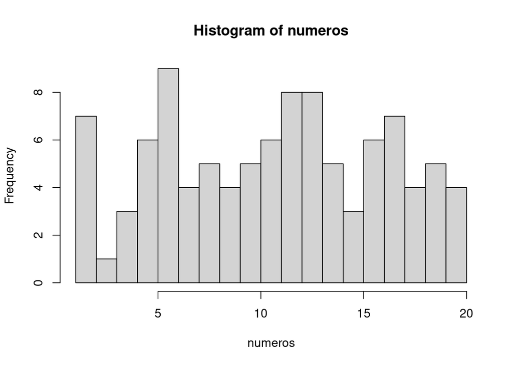

```r
# El argumento breaks nos permite dividir en histograma en las partes que queramos
hist(numeros, breaks = 20)
```

Para obtener un resultado con más precisión, podemos obtener la **moda** si generamos una **tabla de frecuencias** con la función `table` y la función `data.frame`, **aquel elemento con mayor frecuencia será la moda**:

```r
tabla.frecuencias <- data.frame(table(numeros))
tabla.frecuencias
```

```
##    numeros Freq
## 1        1    4
## 2        2    3
## 3        3    1
## 4        4    3
## 5        5    6
## 6        6    9
## 7        7    4
## 8        8    5
## 9        9    4
## 10      10    5
## 11      11    6
## 12      12    8
## 13      13    8
## 14      14    5
## 15      15    3
## 16      16    6
## 17      17    7
## 18      18    4
## 19      19    5
## 20      20    4
```

### 5. Ejercicio 👩‍💻👨‍💻✍

Aplica lo que aprendiste, obten la **mediana**, **media** y **moda** de la siguiente muestra de números:

```r
# Con la función seq, creamos una secuencia de 1 a 10 en intervalos de 0.1 en 0.1
secuencia <- seq(1, 10, 0.1)
muestra <- sample(secuencia, 100, TRUE)
muestra
```

```
##   [1]  7.8  6.3  5.7  6.7  6.7  1.4 10.0  9.9  4.0 10.0  3.8  4.7  2.9  8.7  8.9
##  [16]  7.4  8.2  7.4  3.2  4.8  3.4  1.8  5.1  2.9  1.8  8.0  7.9  1.5  3.3  7.7
##  [31]  5.3  6.4  8.5  8.6  8.5  9.0  8.8  6.2  4.1  3.7  3.5  3.1  1.5  1.6  3.6
##  [46]  6.5  2.3  8.4  1.0  4.7  4.1  1.4  5.0  5.0  5.7  7.6  8.7  8.3  1.4  2.8
##  [61]  8.6  1.5  5.8  8.8  4.2  3.0  3.9  8.1  1.2  3.9  3.3  3.7  3.1  5.8  9.3
##  [76]  8.4  9.8  6.0  2.2  8.7  2.5  1.3  1.7  7.8  3.6  2.0  6.5  3.4  5.9  3.7
##  [91]  7.7  3.5  4.8  7.2  3.4  3.8  5.9  8.9  8.8  5.8
```

##### Mediana

```r
mediana.m <- median(muestra)
mediana
```

```
## [1] 11.5
```

```r
# Aquí el cálculo de la mediana
```

##### Media

```r
media.m <- mean(muestra)
media
```

```
## [1] 11.06
```

```r
# Aquí el cálculo de la media
```

##### Moda

```r
tabla.frecuencias.m <- data.frame(table(muestra))
tabla.frecuencias
```

```
##    numeros Freq
## 1        1    4
## 2        2    3
## 3        3    1
## 4        4    3
## 5        5    6
## 6        6    9
## 7        7    4
## 8        8    5
## 9        9    4
## 10      10    5
## 11      11    6
## 12      12    8
## 13      13    8
## 14      14    5
## 15      15    3
## 16      16    6
## 17      17    7
## 18      18    4
## 19      19    5
## 20      20    4
```

```r
# Aquí el cálculo de la moda
```

💻[Código disponible en RStudio Cloud](https://rstudio.cloud/project/3671022)💻